# Plotting results

## Libraries

```julia
using StatsOrdinalPatterns, CairoMakie, Random
```

## What can be plotted

`StatsOrdinalPatterns.jl` does not depend on a plotting library. Plotting support lives in a package extension that is loaded automatically as soon as Makie, or one of its backends such as `CairoMakie` or `GLMakie`, is loaded next to the package. The extension adds methods to `plot` for two kinds of result objects:

- **Control charts.** `monitor_op` and `monitor_sop` run the EWMA chart over an observed series or image sequence and return a `ControlChartResult`. Its plot shows the chart statistics against the control limit, shades the rejection region and marks the first alarm.
- **Resampled null distributions.** The results of the bootstrap tests (`test_op_bootstrap`, `test_op_bp_bootstrap`, `test_sop_bootstrap`, `test_sop_bp_bootstrap`, `test_acf_bootstrap`, `test_sacf_bootstrap`, `test_sacf_bp_bootstrap`) and of the surrogate test `test_op_surrogate` store the resampled statistics in their `boot_dist` or `surr_dist` field. Their plot is a histogram of that null distribution with the rejection region, the critical value and the observed statistic.

In both cases `plot(res)` returns a `Figure` with a single axis, `plot!(ax, res)` draws into an existing axis, and `plot(fig[i, j], res)` draws into a position of a figure layout.

## Monitoring a time series

The series below is i.i.d. up to $t = 150$ and follows an AR(1) process afterwards. The control limit is calibrated to an in-control ARL of 370, as in the sequential tutorial.

```julia
ic = ContinuousDGPIC(Normal(0, 1))
lam, L0 = 0.1, 370.0

cl = cl_op(
    ic, lam, L0, 0.20;
    chart_choice=Persistence(),
    reps_bracket=1_000, reps_final=2_000, bracket_step=0.02, seed=42
)

Random.seed!(4)
t_change = 150
x = randn(400)
for t in (t_change+1):400
    x[t] = 0.5 * x[t-1] + randn()
end
```

`monitor_op` applies the chart to the series and records the first alarm:

```julia
res = monitor_op(x, lam, cl; chart_choice=Persistence())
```

```
ControlChartResult
  Family:           ordinal patterns (OP)
  Chart:            Persistence()
  λ:                0.1
  Control limit:    0.252
  Alarm rule:       |stat| > cl
  Statistics:       398 (observations 3 to 400)
  First alarm:      observation 178 (statistic 0.2616)
```

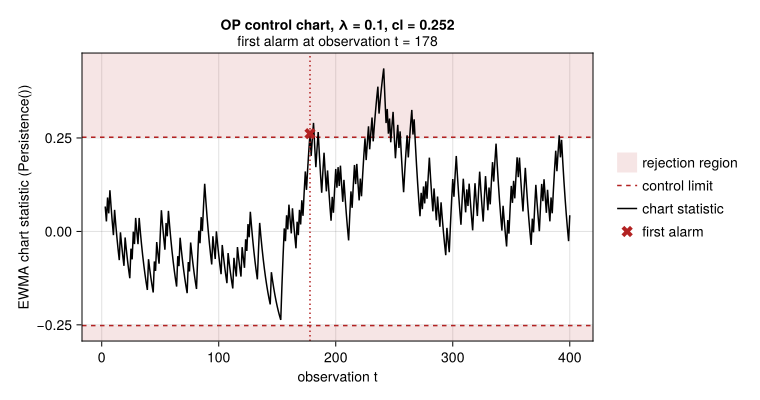

```julia
plot(res)
```

The dashed lines are the control limits, the shaded band is the rejection region and the cross marks the first statistic outside the limits. The x axis is the observation index at which each statistic becomes available, so the alarm can be read off directly as a time point. For the entropy charts the rejection region lies below the limit, and for `DistanceToWhiteNoise()` above it. The plot picks up the direction from the result:

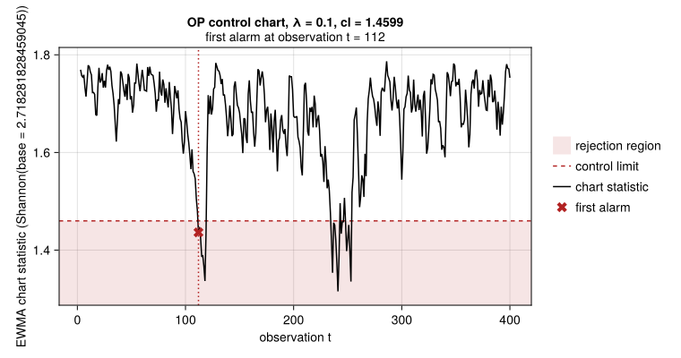

```julia
cl_H = cl_op(
    ic, lam, L0, 1.40;
    chart_choice=Shannon(base=exp(1)),
    reps_bracket=1_000, reps_final=2_000, bracket_step=0.02, seed=42
)
plot(monitor_op(x, lam, cl_H; chart_choice=Shannon(base=exp(1))))
```

## Monitoring an image sequence

The image sequence is spatial white noise up to $t = 20$ and spatially dependent afterwards; `monitor_sop` works on the 3D array and the x axis counts images.

```julia
M, N = 11, 11
ic_spatial = ICSTS(M, N, Normal(0, 1))

cl_sop_ = cl_sop(
    ic_spatial, lam, L0, 0.026, 1, 1;
    chart_choice=TauTilde(),
    reps_bracket=500, reps_final=2_000, bracket_step=0.002, seed=42
)

Random.seed!(42)
T, T_change = 40, 20
images = randn(M, N, T)
for t in (T_change+1):T, i in 2:M, j in 2:N
    images[i, j, t] = 0.4 * (images[i-1, j, t] + images[i, j-1, t]) / 2 + randn()
end
```

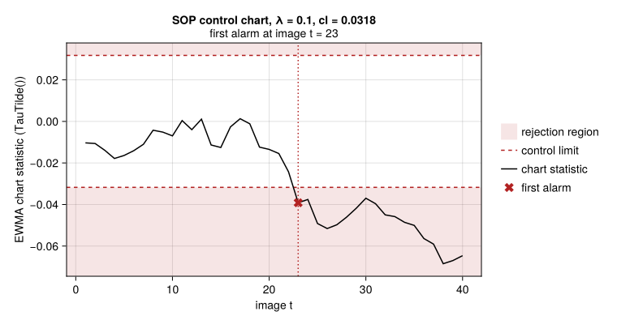

```julia
res_sop = monitor_sop(images, lam, cl_sop_, 1, 1; chart_choice=TauTilde())
plot(res_sop)
```

## Bootstrap null distributions

A bootstrap test resamples the data under the null hypothesis and compares the observed statistic with the resampled ones. The plot shows exactly this comparison:

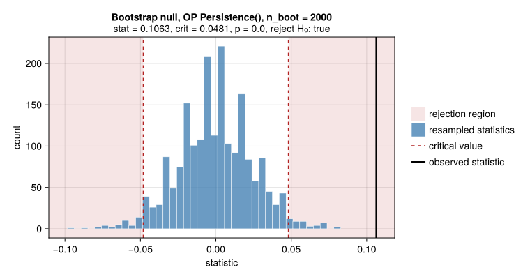

```julia
Random.seed!(42)
n = 300
x_ar = zeros(n)
for t in 2:n
    x_ar[t] = 0.5 * x_ar[t-1] + randn()
end

res_boot = test_op_bootstrap(x_ar, 2_000; chart_choice=Persistence())
plot(res_boot)
```

The histogram is the bootstrap null distribution, the dashed lines are the bootstrap critical values and the solid line is the observed statistic, which here lies far outside the null. The subtitle repeats the fields of the result: the statistic, the critical value, the p value, which is the fraction of resampled statistics at least as extreme as the observed one, and the reject decision.

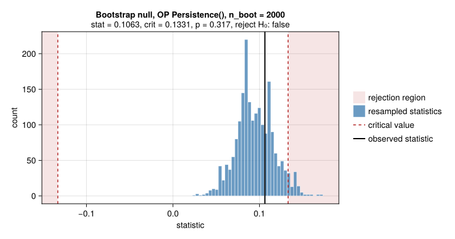

```julia
Random.seed!(42)
plot(test_op_bootstrap(x_ar, 2_000; chart_choice=Persistence(), block_size=20))
```

The same plot exists for the spatial tests and for the Box-Pierce type tests. For the entropy charts the direction of the rejection region is read from the result, so the lower tail is shaded for [`Shannon(base=exp(1))`](https://juliadynamics.github.io/ComplexityMeasures.jl/stable/information_measures/#ComplexityMeasures.Shannon) on a time series and the upper tail for the rescaled statistic of `test_sop_bootstrap`:

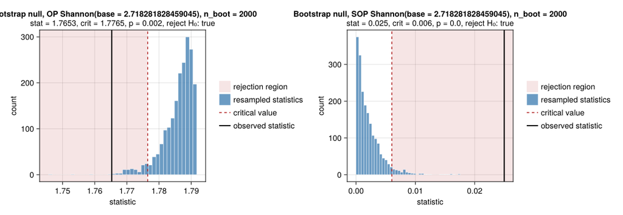

```julia
Random.seed!(42)
img = randn(20, 20)
for i in 2:20, j in 2:20
    img[i, j] = 0.4 * (img[i-1, j] + img[i, j-1]) / 2 + randn()
end

fig = Figure(size=(1100, 380))
plot(fig[1, 1], test_op_bootstrap(x_ar, 2_000; chart_choice=Shannon(base=exp(1))))
plot(fig[1, 2], test_sop_bootstrap(img, 2_000, 1, 1; chart_choice=Shannon(base=exp(1))))
fig
```

The surrogate test `test_op_surrogate`, available once `TimeseriesSurrogates.jl` is loaded, returns an `OPTestResultSurrogate` that is plotted in the same way.

## Customising the figures

`plot` accepts keyword arguments for the figure and the axis, and the remaining keywords control the drawn elements. `plot!` adds the elements to an axis of your own.

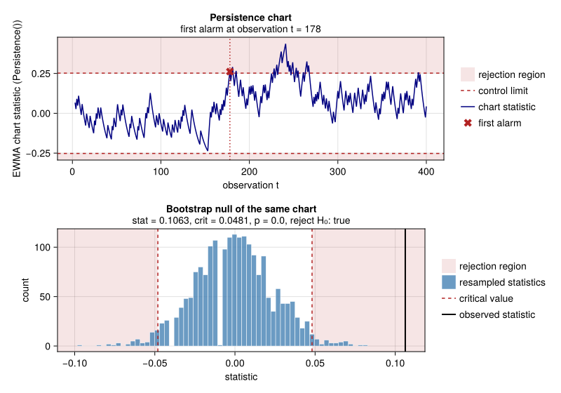

```julia
fig = Figure(size=(800, 560))
plot(fig[1, 1], res; axis=(title="Persistence chart",), color=:navy)
plot(fig[2, 1], res_boot; axis=(title="Bootstrap null of the same chart",), nbins=60)
fig
```

The keywords of the control chart plot are `color`, `linewidth`, `limit_color`, `region_color` and `legend`; those of the null distribution plot are `nbins`, `color`, `stat_color`, `crit_color`, `region_color` and `legend`. The legend sits to the right of the axis by default. Pass `legend=false` to omit it, or a Makie position such as `:lt` to place it inside the axis. `plot!` on an axis of your own always places the legend inside, since it has no layout to put it next to.